# Sixth Week: Linear Models

Sixth Week: Linear Models House price prediction Kayhan Momeni 23 Farvardin 1397

> با توجه به داده های قیمت منازل لطفا به سوالات زیر پاسخ دهید.

ابتدا باید پکیج های مورد نیاز را صدا بزنیم و داده ها را وارد کنیم:

```r
library(readr)
library(dplyr)
library(tidyr)
library(Hmisc)
library(corrplot)
library(ggplot2)
library(PerformanceAnalytics)
library(car)
train = read_csv("/Users/kayhan/Desktop/house/train.csv")
```

##### ۱. ماتریس همبستگی متغیرهای مختلف را به دست آورده و سپس رسم نمایید. اعداد به دست آمده را با آزمون فرض معناداری همبستگی بسنجید و سپس ده متغیری که همبستگی بالاتری با قیمت دارند را مشخص نمایید.

###### پاسخ:

با استفاده از تابع rcorr در کتابخانه ی Hmisc، می توان به راحتی میزان همبستگی متغیرها و مقدار p-value آن ها را حساب کرد:

```r
train %>%
  select(2:81) %>%
  select_if(is.numeric) %>%
  drop_na()->data

corrMatrix = rcorr(as.matrix(data))
```

حالا متغیر corrMatrix حاوی ماتریس همبستگی متغیرها و مقدار p-value آن ها است. از آن جا که ابعاد ماتریس زیاد است، برای نمایش آن از تابع زیر استفاده می کنیم:

```r
ReshapeCorrMatrix <- function(corr, pval)
{
  ut <- upper.tri(corr)
  data.frame(
    row = rownames(corr)[row(corr)[ut]],
    column = rownames(corr)[col(corr)[ut]],
    cor  =(corr)[ut],
    p = pval[ut]
  )
}
head(ReshapeCorrMatrix(corrMatrix$r, corrMatrix$P), 10)
```

```
##            row      column         cor            p
## 1   MSSubClass LotFrontage -0.38693957 0.000000e+00
## 2   MSSubClass     LotArea -0.19809553 2.208589e-11
## 3  LotFrontage     LotArea  0.42118410 0.000000e+00
## 4   MSSubClass OverallQual  0.02952186 3.233760e-01
## 5  LotFrontage OverallQual  0.24132232 2.220446e-16
## 6      LotArea OverallQual  0.16752479 1.674836e-08
## 7   MSSubClass OverallCond -0.08785932 3.239368e-03
## 8  LotFrontage OverallCond -0.04631165 1.212189e-01
## 9      LotArea OverallCond -0.03434795 2.505266e-01
## 10 OverallQual OverallCond -0.16315688 3.941205e-08
```

که ده ردیف اول را نشان می دهید. برای تصویرسازی ماتریس همبستگی، از تابع corrplot در کتابخانه ی corrplot استفاده می کنیم:

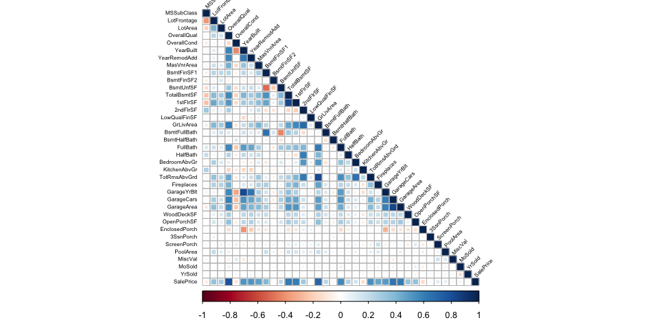

```r
corrplot(corrMatrix$r, method = "square" , type = "lower", order = "original",
         tl.col = "black", tl.cex=0.5, tl.srt = 45)
```

ده متغیری که بیشترین همبستگی را با قیمت فروش دارند هم عبارتند از:

```r
as.data.frame(corrMatrix$r) ->tmp
tmp = tmp[which(rownames(tmp) %in% c("SalePrice"))]
tmp %>%
  mutate(SalePriceABS = abs(SalePrice), variable = rownames(tmp)) %>%
  arrange(-SalePriceABS) %>%
  .[2:11,]->tmp

tmp$variable
```

```
##  [1] "OverallQual"  "GrLivArea"    "GarageCars"   "GarageArea"
##  [5] "TotalBsmtSF"  "1stFlrSF"     "FullBath"     "TotRmsAbvGrd"
##  [9] "YearBuilt"    "YearRemodAdd"
```

##### ۲. در یک تصویر نمودار پراکنش دو به دو ده متغیر بدست آمده به همراه قیمت را رسم نمایید و هم خطی بودن متغیرها را بررسی کنید

###### پاسخ:

ابتدا ۱۰ متغیری که بیشترین همبستگی با قیمت را داشتند به همراه خود متغیر قیمت را از داده ها جدا می کنیم:

```r
train %>%
  select("OverallQual", "GrLivArea", "GarageCars",   "GarageArea", "TotalBsmtSF",
         "1stFlrSF",     "FullBath", "TotRmsAbvGrd", "YearBuilt",  "YearRemodAdd",
         "SalePrice") -> data
```

سپس برای بررسی هم خطی بودن متغیرها، این متغیرها را دو به دو برحسب هم رسم میکنیم. برای رسم این نمودار، از تابع chart.Correlation واقع در کتابخانه ی PerformanceAnalytics استفاده می کنیم:

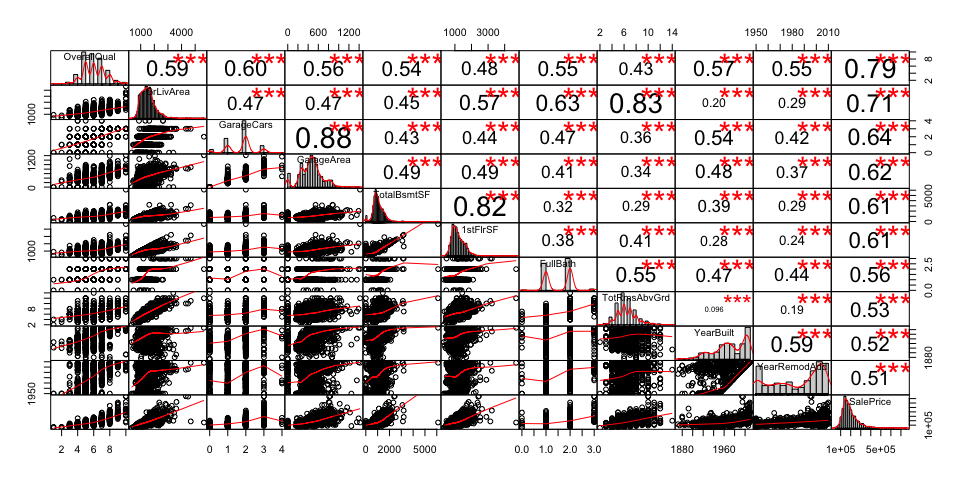

```r
chart.Correlation(data, histogram=TRUE)
```

همچنین با استفاده از تابع scatterplotMatrix از کتابخانه ی car هم خواهیم داشت:

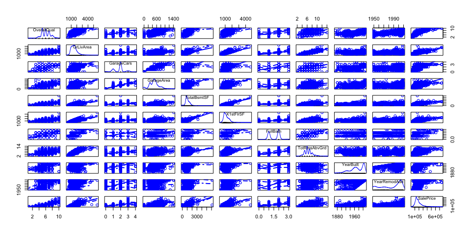

```r
scatterplotMatrix(data)
```

که نمودار بالا، نمودار پراکنش دو به دو متغیرهای تاثیرگذار بر قیمت می باشد.

##### ۳. یک مدل خطی بر اساس ده متغیر برای پیش بینی قیمت برازش دهید. و سپس خلاصه نتایج مدل را به دست آورید.

###### پاسخ:

```r
train %>%
  select("OverallQual",         "GrLivArea", "GarageCars",   "GarageArea", "TotalBsmtSF",
         firstFlrSF="1stFlrSF", "FullBath",  "TotRmsAbvGrd", "YearBuilt",  "YearRemodAdd",
         "SalePrice") -> mydata

model = lm(SalePrice ~ OverallQual + GrLivArea + GarageCars + GarageArea + TotalBsmtSF +
           firstFlrSF + FullBath + TotRmsAbvGrd + YearBuilt + YearRemodAdd, data = mydata)

summary(model)
```

```
##
## Call:
## lm(formula = SalePrice ~ OverallQual + GrLivArea + GarageCars +
##     GarageArea + TotalBsmtSF + firstFlrSF + FullBath + TotRmsAbvGrd +
##     YearBuilt + YearRemodAdd, data = mydata)
##
## Residuals:
##     Min      1Q  Median      3Q     Max
## -489958  -19316   -1948   16020  290558
##
## Coefficients:
##                Estimate Std. Error t value Pr(>|t|)
## (Intercept)  -1.186e+06  1.291e+05  -9.187  < 2e-16 ***
## OverallQual   1.960e+04  1.190e+03  16.472  < 2e-16 ***
## GrLivArea     5.130e+01  4.233e+00  12.119  < 2e-16 ***
## GarageCars    1.042e+04  3.044e+03   3.422 0.000639 ***
## GarageArea    1.495e+01  1.031e+01   1.450 0.147384
## TotalBsmtSF   1.986e+01  4.295e+00   4.625 4.09e-06 ***
## firstFlrSF    1.417e+01  4.930e+00   2.875 0.004097 **
## FullBath     -6.791e+03  2.682e+03  -2.532 0.011457 *
## TotRmsAbvGrd  3.310e+01  1.119e+03   0.030 0.976404
## YearBuilt     2.682e+02  5.035e+01   5.328 1.15e-07 ***
## YearRemodAdd  2.965e+02  6.363e+01   4.659 3.47e-06 ***
## ---
## Signif. codes:  0 '***' 0.001 '**' 0.01 '*' 0.05 '.' 0.1 ' ' 1
##
## Residual standard error: 37920 on 1449 degrees of freedom
## Multiple R-squared:  0.7737, Adjusted R-squared:  0.7721
## F-statistic: 495.4 on 10 and 1449 DF,  p-value: < 2.2e-16
```

##### ۴. نمودار قیمت واقعی و قیمت پیش بینی را رسم نمایید و خوب بودن مدل را ارزیابی کنید.

###### پاسخ:

برای رسم ۴ نمودار معمول در بررسی مدل خطی، از دستور های زیر استفاده می کنیم:

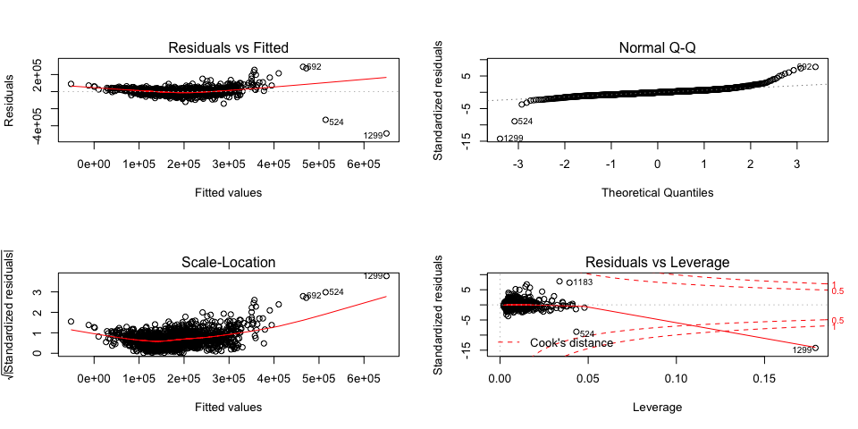

```r
par(mfrow=c(2,2))
plot(model)
```

اما در اینجا به نمودار residuals-fits علاقه ی بیشتری داریم:

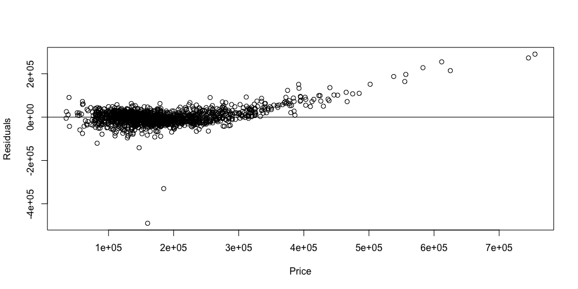

```r
res <- residuals(model)
plot(jitter(res)~jitter(SalePrice), ylab="Residuals", xlab="Price", data=mydata)
abline(0,0)
```

همانطور که مشخص است، برای خانه های با قیمت های بالا، فاصله ی قیمت واقعی از پیش بینی زیاد می شود و مدل ما خوب کار نمی کند. اما خانه هایی با قیمت متوسط را خوب پیش بینی می کند. نمودار قیمت پیش بینی بر حسب قیمت واقعی هم به این صورت است:

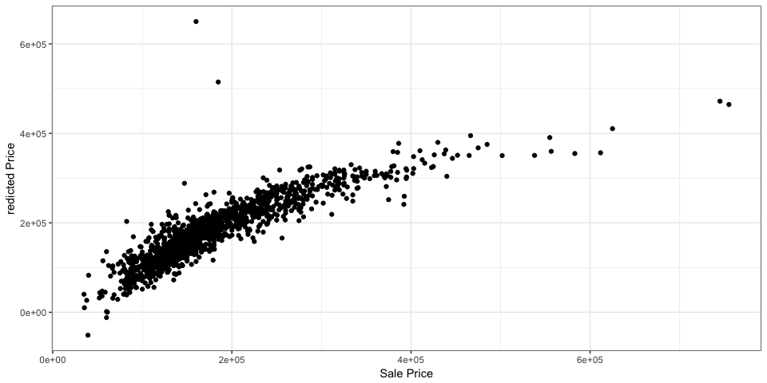

```r
mydata %>%
  mutate(PredictedPrice=1.960e+04*OverallQual + 5.130e+01*GrLivArea + 1.042e+04*GarageCars +
           1.495e+01*GarageArea + 1.986e+01*TotalBsmtSF + 1.417e+01*firstFlrSF + -6.791e+03*FullBath +
           3.310e+01*TotRmsAbvGrd + 2.682e+02*YearBuilt + 2.965e+02*YearRemodAdd -1.186e+06) -> mydata

ggplot(mydata, aes(x=SalePrice, y=PredictedPrice)) + geom_point() +
  xlab("Sale Price")+
  ylab("redicted Price")+
  theme_bw()
```

که مطابق انتظارمان، مدل قیمت خانه هایی با قیمت بالا را کمتر از حد انتظار پیش بینی می کند و برای بهبود آن باید از مدل های غیرخطی استفاده کرد.

##### ۵. مقدار R-squared مدل را به دست آورید. آیا بر اساس این کمیت مدل به خوبی به داده ها برازش داده شده است؟ کمیت F-statistic را در خلاصه مدل تفسیر نمایید.

###### پاسخ:

بیایید یکبار دیگر به خلاصه مدل نگاهی بیاندازیم:

```r
summary(model)
```

```
##
## Call:
## lm(formula = SalePrice ~ OverallQual + GrLivArea + GarageCars +
##     GarageArea + TotalBsmtSF + firstFlrSF + FullBath + TotRmsAbvGrd +
##     YearBuilt + YearRemodAdd, data = mydata)
##
## Residuals:
##     Min      1Q  Median      3Q     Max
## -489958  -19316   -1948   16020  290558
##
## Coefficients:
##                Estimate Std. Error t value Pr(>|t|)
## (Intercept)  -1.186e+06  1.291e+05  -9.187  < 2e-16 ***
## OverallQual   1.960e+04  1.190e+03  16.472  < 2e-16 ***
## GrLivArea     5.130e+01  4.233e+00  12.119  < 2e-16 ***
## GarageCars    1.042e+04  3.044e+03   3.422 0.000639 ***
## GarageArea    1.495e+01  1.031e+01   1.450 0.147384
## TotalBsmtSF   1.986e+01  4.295e+00   4.625 4.09e-06 ***
## firstFlrSF    1.417e+01  4.930e+00   2.875 0.004097 **
## FullBath     -6.791e+03  2.682e+03  -2.532 0.011457 *
## TotRmsAbvGrd  3.310e+01  1.119e+03   0.030 0.976404
## YearBuilt     2.682e+02  5.035e+01   5.328 1.15e-07 ***
## YearRemodAdd  2.965e+02  6.363e+01   4.659 3.47e-06 ***
## ---
## Signif. codes:  0 '***' 0.001 '**' 0.01 '*' 0.05 '.' 0.1 ' ' 1
##
## Residual standard error: 37920 on 1449 degrees of freedom
## Multiple R-squared:  0.7737, Adjusted R-squared:  0.7721
## F-statistic: 495.4 on 10 and 1449 DF,  p-value: < 2.2e-16
```

همانطور که مشخص است، میزان $R^{2}$ در مدل ما برابر با 0.7721 می باشد. می دانیم هرچه این عدد (که مقداری بین ۰ و ۱ دارد)، هرچه بیشتر به ۱ نزدیک باشد، نشانگر این است که پیش بینی ما به واقعیت نزدیک تر است و بنابراین در اینجا با مدل نسبتا خوبی مواجه هستیم.

همچنین مقدار F-statistic برابر با 495.4 می باشد که دارای p-value بسیار پایینی است. در واقع $Pr(F)$ بیانگر این است که با چه احتمالی این فرض که «همه ی متغیرهای دخیل در مدل، دارای ضریب ۰ باشند یا به عبارت دیگر، تفاوت نقاط صرفا از نویز خالص حاصل شود و متغیرها در میزان قیمت تاثیری نداشته باشند» چقدر است. با توجه به پایین بودن $Pr(F)$ میتوان نتیجه گرفت که حداقل برخی از متغیرهایی که در مدلمان استفاده کرده ایم، واقعا در میزان قیمت موثر اند.

##### ۶. بر اساس p-value سطح معناداری ضرایب تصمیم بگیرید که چه متغیرهایی در مدل سازی استفاده شود. بر اساس متغیرهای جدید دوباره مدل سازی کنید و نتایج رو گزارش دهید.

###### پاسخ:

بیایید یکبار دیگر به خلاصه مدل نگاهی بیاندازیم:

```r
summary(model)
```

```
##
## Call:
## lm(formula = SalePrice ~ OverallQual + GrLivArea + GarageCars +
##     GarageArea + TotalBsmtSF + firstFlrSF + FullBath + TotRmsAbvGrd +
##     YearBuilt + YearRemodAdd, data = mydata)
##
## Residuals:
##     Min      1Q  Median      3Q     Max
## -489958  -19316   -1948   16020  290558
##
## Coefficients:
##                Estimate Std. Error t value Pr(>|t|)
## (Intercept)  -1.186e+06  1.291e+05  -9.187  < 2e-16 ***
## OverallQual   1.960e+04  1.190e+03  16.472  < 2e-16 ***
## GrLivArea     5.130e+01  4.233e+00  12.119  < 2e-16 ***
## GarageCars    1.042e+04  3.044e+03   3.422 0.000639 ***
## GarageArea    1.495e+01  1.031e+01   1.450 0.147384
## TotalBsmtSF   1.986e+01  4.295e+00   4.625 4.09e-06 ***
## firstFlrSF    1.417e+01  4.930e+00   2.875 0.004097 **
## FullBath     -6.791e+03  2.682e+03  -2.532 0.011457 *
## TotRmsAbvGrd  3.310e+01  1.119e+03   0.030 0.976404
## YearBuilt     2.682e+02  5.035e+01   5.328 1.15e-07 ***
## YearRemodAdd  2.965e+02  6.363e+01   4.659 3.47e-06 ***
## ---
## Signif. codes:  0 '***' 0.001 '**' 0.01 '*' 0.05 '.' 0.1 ' ' 1
##
## Residual standard error: 37920 on 1449 degrees of freedom
## Multiple R-squared:  0.7737, Adjusted R-squared:  0.7721
## F-statistic: 495.4 on 10 and 1449 DF,  p-value: < 2.2e-16
```

حالا تنها متغیرهایی که ۳ ستاره و ۲ ستاره هستند (پی ویلیویی کمتر از یک صدم دارند) را در نظر میگیریم و مدلمان را دوباره میسازیم:

```r
model = lm(SalePrice ~ OverallQual + GrLivArea + GarageCars + firstFlrSF +
           TotalBsmtSF + YearBuilt + YearRemodAdd, data = mydata)

summary(model)
```

```
##
## Call:
## lm(formula = SalePrice ~ OverallQual + GrLivArea + GarageCars +
##     firstFlrSF + TotalBsmtSF + YearBuilt + YearRemodAdd, data = mydata)
##
## Residuals:
##     Min      1Q  Median      3Q     Max
## -471221  -19922   -1681   16246  291326
##
## Coefficients:
##                Estimate Std. Error t value Pr(>|t|)
## (Intercept)  -1.075e+06  1.217e+05  -8.833  < 2e-16 ***
## OverallQual   1.949e+04  1.190e+03  16.377  < 2e-16 ***
## GrLivArea     4.768e+01  2.713e+00  17.576  < 2e-16 ***
## GarageCars    1.381e+04  1.820e+03   7.586 5.85e-14 ***
## firstFlrSF    1.407e+01  4.925e+00   2.856  0.00435 **
## TotalBsmtSF   2.174e+01  4.249e+00   5.117 3.53e-07 ***
## YearBuilt     2.292e+02  4.799e+01   4.777 1.96e-06 ***
## YearRemodAdd  2.768e+02  6.337e+01   4.367 1.35e-05 ***
## ---
## Signif. codes:  0 '***' 0.001 '**' 0.01 '*' 0.05 '.' 0.1 ' ' 1
##
## Residual standard error: 38010 on 1452 degrees of freedom
## Multiple R-squared:  0.7722, Adjusted R-squared:  0.7711
## F-statistic: 703.2 on 7 and 1452 DF,  p-value: < 2.2e-16
```

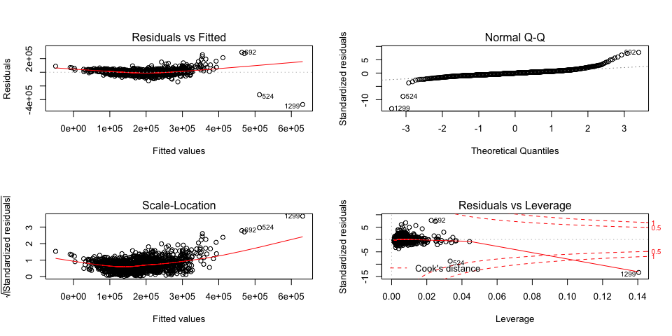

```r
par(mfrow=c(2,2))
plot (model)
```

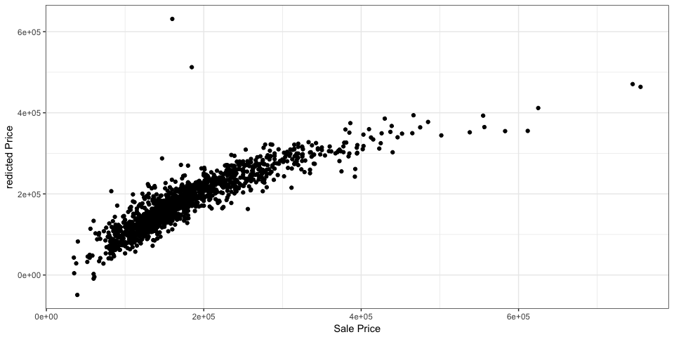

```r
mydata %>%
  mutate(PredictedPrice=1.949e+04*OverallQual + 4.768e+01*GrLivArea + 1.381e+04*GarageCars +
           1.407e+01*firstFlrSF + 2.174e+01*TotalBsmtSF + 2.292e+02*YearBuilt +
           2.768e+02*YearRemodAdd -1.075e+06) -> mydata

ggplot(mydata, aes(x=SalePrice, y=PredictedPrice)) + geom_point() +
  xlab("Sale Price")+
  ylab("redicted Price")+
  theme_bw()
```

همانطور که مشخص است، مدل جدید در میزان خوب بودن با مدل قبلی چندان تفاوتی ندارد اما از آن ساده تر می باشد.

##### ۷. مدل خود را بر اساس باقی مانده نقص یابی کنید. سه محک normality, independance, Constant Variance را در نقص یابی خود در نظر بگیرید.

###### پاسخ:

برای عیب یابی مدل، باید از نمودارهای عیب یابی استفاده کنیم. این نمودار ها را در سوال های قبل رسم کرده ایم. در این سوال مجددا آن ها را تحلیل می کنیم. به طور کلی در برازش یک مدل خطی به داده ها، ۴ فرض وجود دارد:

۱- خطی بودن رابطه

۲- ثابت بودن واریانس رزیجوال ها

۳- استقلال رزیجوال ها از هم

۴- نرمال بودن توزیع رزیجوال ها

نمودار نخست، نمودار residuals-fitted می باشد:

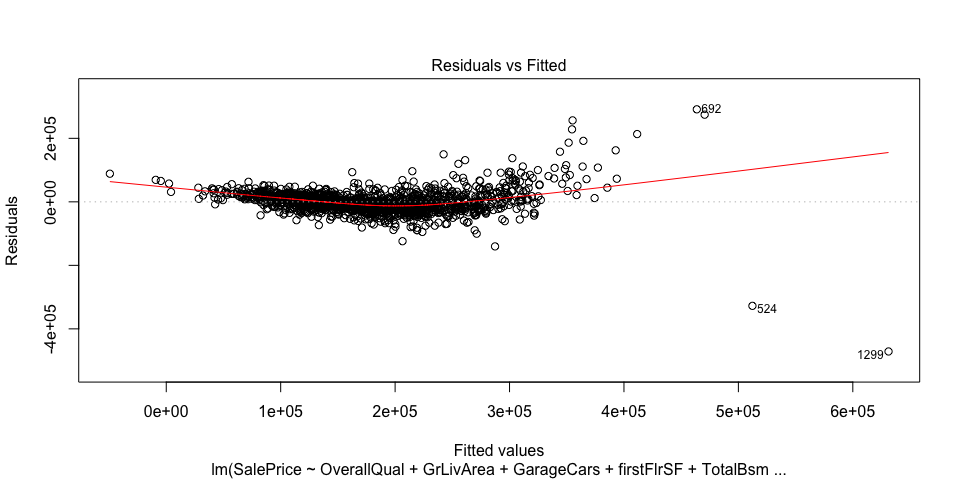

```r
plot(model, which=1)
```

همانطور که مشخص است، داده ها در نمودار بالا دارای یک الگو هستند. یعنی در خانه هایی با قیمت بالا، رزیجوال ها بزرگ می شوند که یعنی مدل خطی، مدل خیلی مناسبی برای برازش نیست. نمودار دوم، نمودار QQ-plot است:

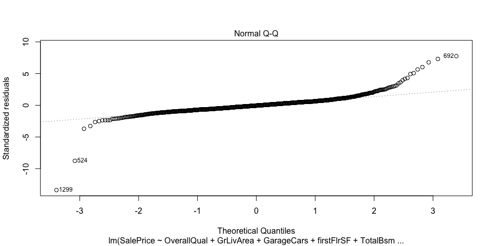

```r
plot(model, which=2)
```

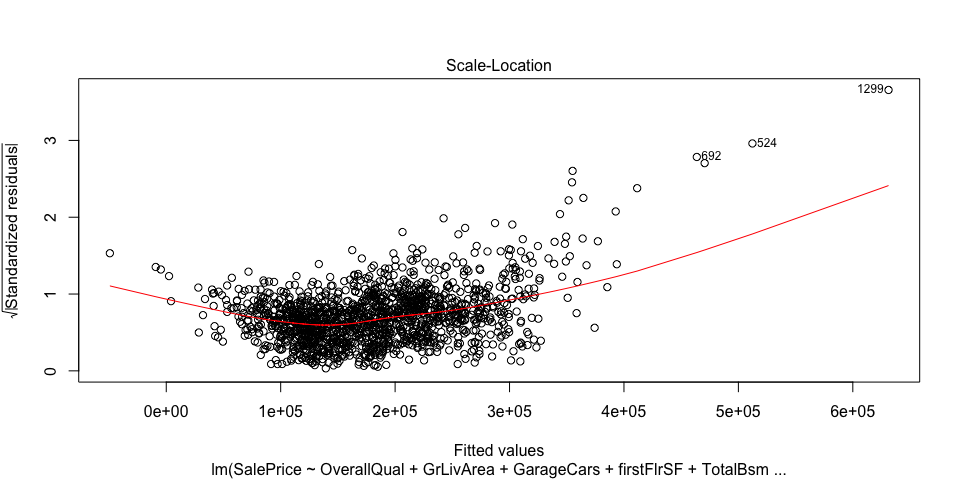

```r
plot(model, which=3)
```

همانطور که مشخص است، به ازای مقادیر بالاتر، نقاط بیشتر حول خط پراکنده شده اند. به نظر می رسد که فرض ثابت بودن واریانس رزیجوال ها، فرض درستی نبوده است:

```r
ncvTest(model)
```

```
## Non-constant Variance Score Test
## Variance formula: ~ fitted.values
## Chisquare = 2777.921    Df = 1     p = 0
```

که چون p-value بسیار پایین است، بنابر این واریانس رزیجوال ها به ازای قیمت های مختلف ثابت نیست. در نهایت هم برای تست استقلال رزیجوال ها از هم، از آزمون فرض Durbin-Watson استفاده می کنیم:

```r
durbinWatsonTest(model)
```

```
##  lag Autocorrelation D-W Statistic p-value
##    1       0.0107856      1.978339   0.676
##  Alternative hypothesis: rho != 0
```

##### ۸. داده ها را به پنج قسمت تقسیم کنید. بر اساس چهار قسمت مدل خطی را بسازید و صحت مدل را برای یک قسمت باقی مانده را تست کنید. خطای پیش بینی شما چقدر است؟

###### پاسخ:

ابتدا داده ها را به ۵ قسمت تقسیم می کنیم و مدل سازی را با ۷ کمیتی که پیش از این نیز از آن استفاده کردیم، روی ۴ قسمت انجام می دهیم. سپس مدل به دست آمده را برای پیش بینی قسمت پنجم از داده ها به کار می بریم:

```r
colnames(train)[44] <- "firstFlrSF"
mydata = split(train, sample(1:5, nrow(train), replace=T))
data = mydata[1:4]
data1 = do.call("rbind", data)
data = mydata[5]
data2 = do.call("rbind", data)
model = lm(SalePrice ~ OverallQual + GrLivArea + GarageCars + firstFlrSF +
             TotalBsmtSF + YearBuilt + YearRemodAdd, data = data1)
data2$PredictPrice = predict(model, data2)
data2 %>%
  mutate(error = (PredictPrice-SalePrice)/SalePrice, absError = abs(error)) -> data2
```

برای محاسبه ی میزان خطای پیش بینی، از رابطه ی زیر استفاده می کنیم:

$\frac{PredictedPrice-SalePrice}{SalePrice}$

هستوگرام خطاها به صورت زیر است:

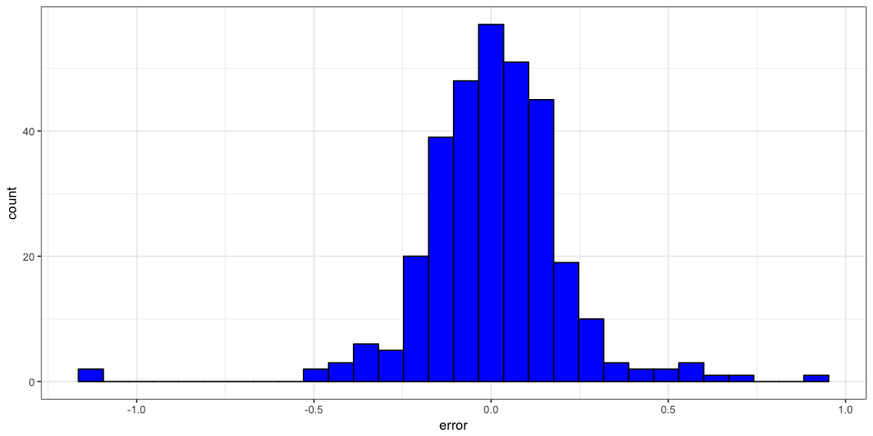

```r
ggplot(data2, aes(x=error)) + geom_histogram(color="black", fill="blue") + theme_bw()
```

همچنین نمودار جعبه ای خطاها هم برحسب شرایط خرید، به صورت زیر است:

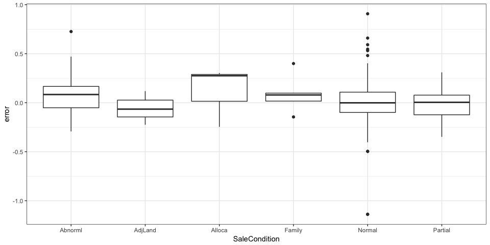

```r
ggplot(data2, aes(x=SaleCondition, y=error)) + geom_boxplot() + theme_bw()
```

به طور میانگین هم خطای پیش بینی برابر است با:

```r
cat(mean(data2$absError*100),"%")
```

```
## 14.35984 %
```

##### ۹. آیا قیمت ربط غیر خطی با یکی از ده متغیر استفاده شده دارد؟ بر اساس دستاوردهای خود مدل را بهتر نمایید.

###### پاسخ:

ابتدا مدلی با استفاده ااز توان اول و دوم هر ۱۰ متغیر میسازیم:

```r
model = lm(SalePrice ~ OverallQual + GrLivArea + GarageCars + GarageArea + TotalBsmtSF +
             firstFlrSF + FullBath + TotRmsAbvGrd + YearBuilt + YearRemodAdd + I(OverallQual^2) +
             I(GrLivArea^2) + I(GarageCars^2) + I(GarageArea^2) + I(TotalBsmtSF^2) +
             I(firstFlrSF^2) + I(FullBath^2) + I(TotRmsAbvGrd^2) + I(YearBuilt^2) +
             I(YearRemodAdd^2) , data = train)

summary(model)
```

```
##
## Call:
## lm(formula = SalePrice ~ OverallQual + GrLivArea + GarageCars +
##     GarageArea + TotalBsmtSF + firstFlrSF + FullBath + TotRmsAbvGrd +
##     YearBuilt + YearRemodAdd + I(OverallQual^2) + I(GrLivArea^2) +
##     I(GarageCars^2) + I(GarageArea^2) + I(TotalBsmtSF^2) + I(firstFlrSF^2) +
##     I(FullBath^2) + I(TotRmsAbvGrd^2) + I(YearBuilt^2) + I(YearRemodAdd^2),
##     data = train)
##
## Residuals:
##     Min      1Q  Median      3Q     Max
## -360513  -15901    -324   14468  248988
##
## Coefficients:
##                     Estimate Std. Error t value Pr(>|t|)
## (Intercept)        1.828e+07  1.212e+07   1.509 0.131525
## OverallQual       -4.375e+04  4.654e+03  -9.399  < 2e-16 ***
## GrLivArea          4.828e+01  9.716e+00   4.969 7.53e-07 ***
## GarageCars        -1.071e+04  8.342e+03  -1.284 0.199522
## GarageArea         4.147e+01  2.895e+01   1.433 0.152134
## TotalBsmtSF        5.758e+01  6.508e+00   8.848  < 2e-16 ***
## firstFlrSF         4.505e+01  1.327e+01   3.395 0.000705 ***
## FullBath          -3.852e+04  9.411e+03  -4.092 4.51e-05 ***
## TotRmsAbvGrd      -4.932e+03  3.684e+03  -1.339 0.180875
## YearBuilt          2.902e+04  4.764e+03   6.091 1.44e-09 ***
## YearRemodAdd      -4.774e+04  1.300e+04  -3.673 0.000248 ***
## I(OverallQual^2)   5.210e+03  3.728e+02  13.977  < 2e-16 ***
## I(GrLivArea^2)     2.460e-03  2.348e-03   1.048 0.294960
## I(GarageCars^2)    5.196e+03  1.962e+03   2.648 0.008193 **
## I(GarageArea^2)   -2.128e-02  2.241e-02  -0.950 0.342499
## I(TotalBsmtSF^2)  -1.443e-02  2.703e-03  -5.340 1.08e-07 ***
## I(firstFlrSF^2)   -1.374e-02  5.209e-03  -2.637 0.008465 **
## I(FullBath^2)      1.121e+04  2.900e+03   3.867 0.000115 ***
## I(TotRmsAbvGrd^2)  2.567e+02  2.516e+02   1.020 0.307724
## I(YearBuilt^2)    -7.344e+00  1.220e+00  -6.021 2.19e-09 ***
## I(YearRemodAdd^2)  1.217e+01  3.285e+00   3.704 0.000220 ***
## ---
## Signif. codes:  0 '***' 0.001 '**' 0.01 '*' 0.05 '.' 0.1 ' ' 1
##
## Residual standard error: 32340 on 1439 degrees of freedom
## Multiple R-squared:  0.8365, Adjusted R-squared:  0.8343
## F-statistic: 368.2 on 20 and 1439 DF,  p-value: < 2.2e-16
```

سپس پارامترهایی که تاثیر چندانی در مدل نداشتند را از مدل حذف می کنیم و مجددا مدل را میسازیم:

```r
model = lm(SalePrice ~ OverallQual + GrLivArea + TotalBsmtSF +
             firstFlrSF + FullBath + YearBuilt + YearRemodAdd + I(OverallQual^2) +
             I(GrLivArea^2) + I(GarageCars^2)  + I(TotalBsmtSF^2) +
             I(firstFlrSF^2) + I(FullBath^2)   + I(YearBuilt^2) +
             I(YearRemodAdd^2) , data = train)

summary(model)
```

```
##
## Call:
## lm(formula = SalePrice ~ OverallQual + GrLivArea + TotalBsmtSF +
##     firstFlrSF + FullBath + YearBuilt + YearRemodAdd + I(OverallQual^2) +
##     I(GrLivArea^2) + I(GarageCars^2) + I(TotalBsmtSF^2) + I(firstFlrSF^2) +
##     I(FullBath^2) + I(YearBuilt^2) + I(YearRemodAdd^2), data = train)
##
## Residuals:
##     Min      1Q  Median      3Q     Max
## -365043  -15763     -41   14474  249719
##
## Coefficients:
##                     Estimate Std. Error t value Pr(>|t|)
## (Intercept)        1.703e+07  1.206e+07   1.413 0.157948
## OverallQual       -4.448e+04  4.451e+03  -9.993  < 2e-16 ***
## GrLivArea          3.896e+01  8.111e+00   4.804 1.72e-06 ***
## TotalBsmtSF        5.903e+01  6.420e+00   9.195  < 2e-16 ***
## firstFlrSF         4.740e+01  1.318e+01   3.597 0.000332 ***
## FullBath          -4.032e+04  9.376e+03  -4.301 1.82e-05 ***
## YearBuilt          2.904e+04  4.749e+03   6.116 1.23e-09 ***
## YearRemodAdd      -4.652e+04  1.296e+04  -3.590 0.000342 ***
## I(OverallQual^2)   5.280e+03  3.579e+02  14.751  < 2e-16 ***
## I(GrLivArea^2)     4.196e-03  2.064e-03   2.033 0.042220 *
## I(GarageCars^2)    3.526e+03  4.675e+02   7.543 8.07e-14 ***
## I(TotalBsmtSF^2)  -1.493e-02  2.650e-03  -5.634 2.12e-08 ***
## I(firstFlrSF^2)   -1.433e-02  5.184e-03  -2.764 0.005777 **
## I(FullBath^2)      1.158e+04  2.892e+03   4.003 6.58e-05 ***
## I(YearBuilt^2)    -7.347e+00  1.216e+00  -6.043 1.92e-09 ***
## I(YearRemodAdd^2)  1.186e+01  3.275e+00   3.620 0.000304 ***
## ---
## Signif. codes:  0 '***' 0.001 '**' 0.01 '*' 0.05 '.' 0.1 ' ' 1
##
## Residual standard error: 32360 on 1444 degrees of freedom
## Multiple R-squared:  0.8358, Adjusted R-squared:  0.8341
## F-statistic: 489.9 on 15 and 1444 DF,  p-value: < 2.2e-16
```

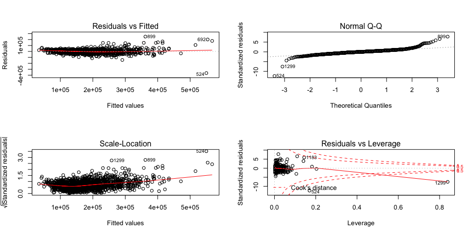

```r
par(mfrow=c(2,2))
plot (model)
```

بیایید سوال قبل را بر روی مدل جدید مجددا اجرا کنیم:

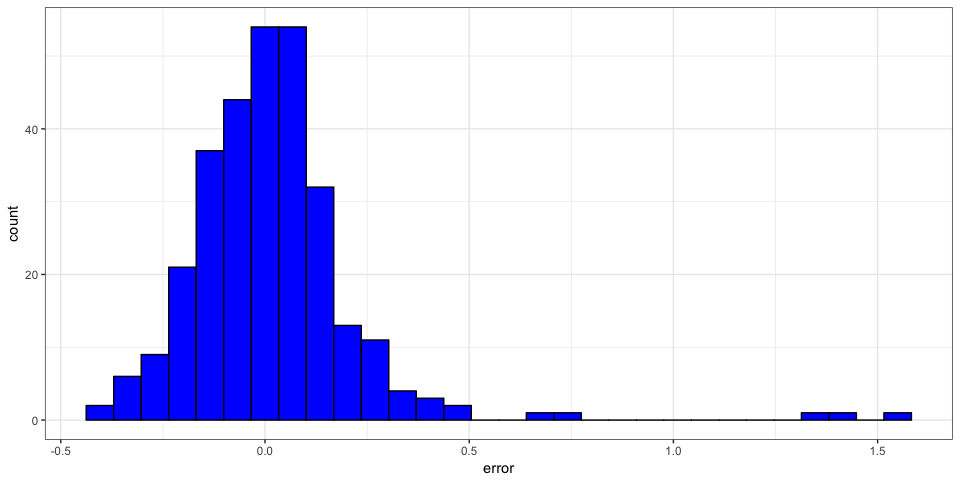

```r
colnames(train)[44] <- "firstFlrSF"
mydata = split(train, sample(1:5, nrow(train), replace=T))
data = mydata[1:4]
data1 = do.call("rbind", data)
data = mydata[5]
data2 = do.call("rbind", data)

data2$PredictPrice = predict(model, data2)
data2 %>%
  mutate(error = (PredictPrice-SalePrice)/SalePrice, absError = abs(error)) -> data2

ggplot(data2, aes(x=error)) + geom_histogram(color="black", fill="blue") + theme_bw()
```

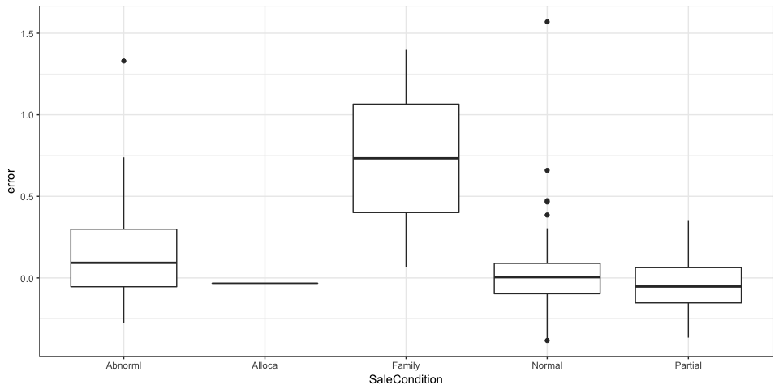

```r
ggplot(data2, aes(x=SaleCondition, y=error)) + geom_boxplot() + theme_bw()
```

```r
cat(mean(data2$absError*100),"%")
```

```
## 13.48751 %
```

همانطور که مشخص است، مدل اندکی بهبود یافته است.

##### ۱۰. بر اساس مدل نهایی به دست آمده نتایج پیش بینی خود را بر روی test.csv به دست آورید و در سایت kaggle در مسابقه House Prices: Advanced Regression Techniques بارگذاری نمایید. سپس لینک رتبه و عدد آن را ضمیمه تمرین کنید.

###### پاسخ:

لینک مسابقه:

[House Prices: Advanced Regression Techniques](https://www.kaggle.com/c/house-prices-advanced-regression-techniques)

لینک پروفایل من در kaggle:

[KayhanMomeni](https://www.kaggle.com/kayhanmomeni)

که پس از ثبت مدل بالا در این مسابقه، امتیاز 0.18895 و رتبه ی 3336 از 4752 را کسب کردم!

[figure not shown]